# Univariate Kalman Filter and Smoother

Ewok

August 15, 2016

## Equations

The following equations that govern the Kalman Filter and Smoother can be found online [here](https://cse.sc.edu/~terejanu/files/tutorialKS.pdf):

| **Model and Observation** |  |
| --- | --- |
| Model and Observation | $x_k = F_{k-1}x_{k-1} + B_{k-1}u_{k-1}+w_{k-1}$ |
|  | $z_k = H_kx_k+v_k$ |
| **Forward Filter** |  |
| Initialization | $x_{f0}^+ = \mu_0$ with error covariance $P_{f0}^+$ |
| Model Forecast Step/Predictor | $x_{fk}^- = F_{k-1}x_{fk-1}^+ + B_{k-1}u_{k-1}$ |
|  | $P_{fk}^- = F_{k-1}P_{fk-1}^+F_{k-1}^T + Q_{k-1}$ |
| Data Assimilation Step/Corrector | $x_{fk}^+=x_{fk}^-+K_{fk}(z_k-H_kx_{fk}^-)$ |
|  | $K_{fk} = P_{fk}^-H_k^T(H_kP_{fk}^-H_k^T+R_k)^{-1}$ |
|  | $P_{fk}^+ = (I-K_{fk}H_k)P_{fk}^-$ |
| **Smoother** |  |
| Initialization | $x_N^s = x_{fk}^+$ |
|  | $P_N^s = P_{fk}^+$ |
| Update | $K_k^s = P_{fk}^+F_k^T(P_{fk+1}^-)^{-1}$ |
|  | $P_k^s = P_{fk}^+-K_k^s(P_{fk+1}^- - P_{k+1}^s)(K_k^s)^T$ |
|  | $x_k^s = x_{fk}^++K_k^s(x_{k+1}^s-x_{fk+1}^-)$ |

## Kalman Filter

Utilized http://www.bzarg.com/p/how-a-kalman-filter-works-in-pictures/ for the following explanation.

The Kalman filter first creates a new best estimate for the state, which is a prediction made from the previous best estimate plus a correction for known external influences. The new uncertainty is predicted from the old uncertainty, with some additional uncertainty from the environment. We also have observed measurements along with associated measurement error. The modeling variable transforms the observed measurement into the same form (units and scale) as the state. The Kalman gain uses the errors of the process and measurement. Then the final state prediction is given by the predicted state plus the kalman gain multiplied by the different between the measurent and the transformed state prediction.The final uncertainty is given by the uncertainty prediction multiplied by one minus the kalman gain times the transformation.

```r
# kalmanfilter.R
# Created by Eric Walker on 2016-08-09.
# Email: ewalke31@jhu.edu
# Copyright (c) 2016. All rights reserved.
#
# an implementation of a univariate kalman filter
#
# f state transition variable
# b control variable
# u control
# h observation variable (model transformation)
# x initial state estimate
# p initial variance estimate (overall error)
# z measurement list
# q environment noise
# r measurement noise
# n number of steps
kalmanfilter <- function(f, b, u, h, x, p, z, q, r, n=length(z)) {
  if (length(z) < n) {
    return(NULL)
  }
  curr.state <- vector(, n)
  curr.prob <- vector(, n)
  curr.state[1] <- x
  curr.prob[1] <- p
  for (i in 1:n) {
    pred.state <- if(i == 1) f * curr.state[i] + b * u else f * curr.state[i-1] + b * u
    pred.prob <- if(i == 1) f * curr.prob[i] * f + q else f * curr.prob[i-1] * f + q
    obs <- z[[i]] - h * pred.state
    obs.cov <- h * pred.prob * h + r
    kalman.gain <- if (obs.cov == 0) 0 else pred.prob * h / obs.cov
    curr.state[i] <- pred.state + kalman.gain * obs
    curr.prob[i] <- (1 - kalman.gain * h) * pred.prob
  }
  return(list(state = curr.state, uncertainty = curr.prob))
}
```

The following code describes the previous value predictor:

```r
# prevstep.R
# Created by Eric Walker on 2016-08-09.
# Email: ewalke31@jhu.edu
# Copyright (c) 2016. All rights reserved.
#
# an implementation of a previous value predictor
#
# x initial state estimate
# z measurement list
# n number of steps
prevstep <- function(x, z, n = length(z)) {
  if (length(z) < n) {
    return(NULL)
  }
  current.state <- vector(, n)
  current.state[1] = x
  for (i in 1:(n-1)) {
    current.state[i+1] <- z[[i]]
  }
  return(current.state)
}
```

Let’s try a very basic test of the Kalman Filter. Applied to a 15-point series of all 5’s with 0 error, the filter, which is given an initial estimate of 5, stays on the value and has no error.

```r
series <- rep(5, 15)
kalmanfilter(1, 0, 0, 1, 5, 1, series, 0, 0, 15)
```

```
## $state
##  [1] 5 5 5 5 5 5 5 5 5 5 5 5 5 5 5
##
## $uncertainty
##  [1] 0 0 0 0 0 0 0 0 0 0 0 0 0 0 0
```

If we start the filter with an incorrect initial estimate of 2 but still 0 error and an inital estimate of 0 covariance, it incorrectly stays on the initial estimate as expected.

```r
series <- rep(5, 15)
kalmanfilter(1, 0, 0, 1, 2, 0, series, 0, 0, 15)
```

```
## $state
##  [1] 2 2 2 2 2 2 2 2 2 2 2 2 2 2 2
##
## $uncertainty
##  [1] 0 0 0 0 0 0 0 0 0 0 0 0 0 0 0
```

```r
series <- rep(5, 15)
kalmanfilter(1, 0, 0, 1, 4, 1, series, 0, 0.001, 15)
```

```
## $state
##  [1] 4.999001 4.999500 4.999667 4.999750 4.999800 4.999833 4.999857
##  [8] 4.999875 4.999889 4.999900 4.999909 4.999917 4.999923 4.999929
## [15] 4.999933
##
## $uncertainty
##  [1] 9.990010e-04 4.997501e-04 3.332223e-04 2.499375e-04 1.999600e-04
##  [6] 1.666389e-04 1.428367e-04 1.249844e-04 1.110988e-04 9.999000e-05
## [11] 9.090083e-05 8.332639e-05 7.691716e-05 7.142347e-05 6.666222e-05
```

Let’s try an intermediate example using a sine wave with added normally distributed noise.

```r
t <- seq(0,4*pi,,100)
actual <- sin(t)
measure <- actual + rnorm(100, mean=0, sd=0.25)
kf <- kalmanfilter(1, 0, 0, 1, 0, 1, measure, 0.001, 0.001, 100)
pv = prevstep(0, measure, 100)
mse_km <- sum((actual-kf$state)^2)
mse_pv <- sum((actual-pv)^2)
rsq_km <- cor(actual, kf$state)^2
rsq_pv <- cor(actual, pv)^2
```

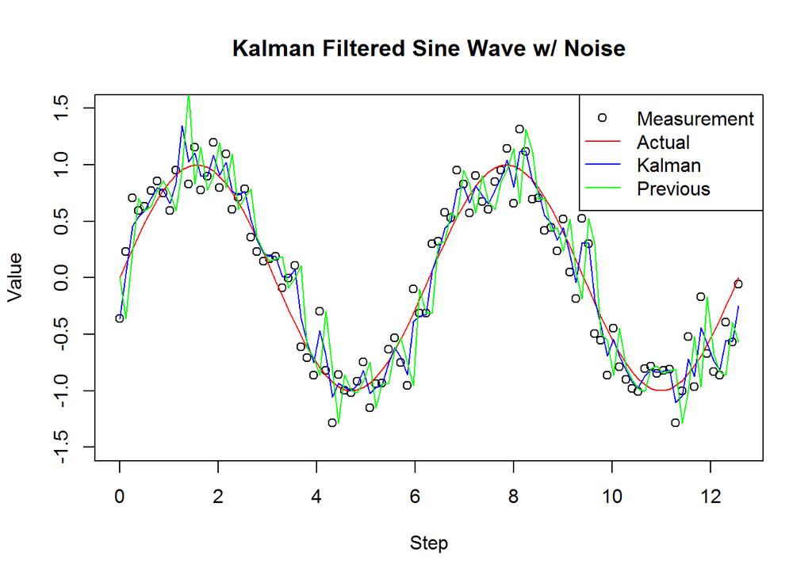

Kalman Filter Mean Squared Error:

```
## [1] 3.172164
```

Kalman Filter R-Squared:

```
## [1] 0.9398694
```

Previous Value Predictor Mean Squared Error:

```
## [1] 6.921754
```

Previous Value Predictor R-Squared:

```
## [1] 0.8780298
```

Now a slightly more in-depth example (adapted from [here](http://greg.czerniak.info/guides/kalman1/)):

We use the following state transition equation: $V_n = V_{n-1} + w_n$ where $w_n$ is the measurement error.

Let’s consider that we are measuring a voltage that we know to be 1.25 V. We can create simulated data for a voltometer by making a normally distributed 100-point timeseries with a mean of 1.25 and a standard deviation of 0.25. Now we use our Kalman filter with the state transition varible being 1 because the voltage is constant, no control variable, a measurement model of 1 since we measure voltage directly, an inital voltage estimate of 2 Volts, an initial covariance estimate of 1, a process error of 0.00001 and a measurement error of 0.1.

We also employ the use of the previous value predictor, which simply predicts the next value as that of the one before it.

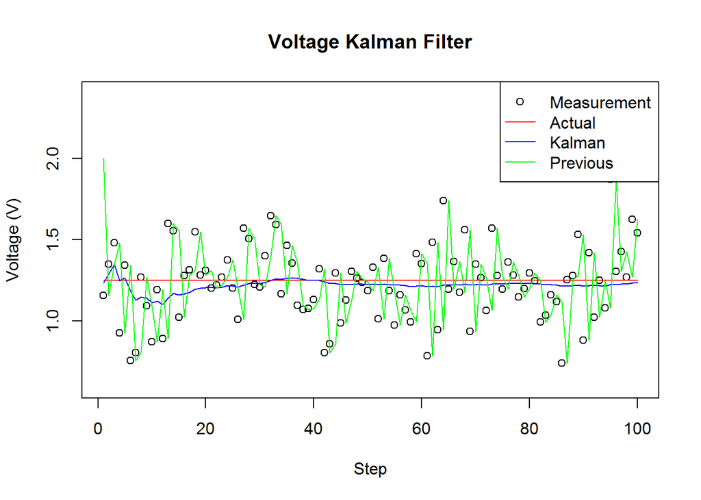

```r
step <- c(1:100)
actual <- rep(1.25, 100)
measure <- rnorm(100, mean=1.25, sd=0.25)
kf = kalmanfilter(1, 0, 0, 1, 2, 1, measure, 0.00001, 0.1, 100)
pv = prevstep(2, measure, 100)
plot(step, measure, xlab="Step", ylab="Voltage (V)", ylim=c(0.6,2.4), main="Voltage Kalman Filter")
lines(step, actual, col="red")
lines(step, kf$state, col="blue")
lines(step, pv, col="green")
legend("topright", c("Measurement", "Actual", "Kalman", "Previous"), lty=c(0,1,1,1), pch=c(1,-1,-1,-1), col=c("black", "red", "blue", "green"))
```

```r
mse_km <- sum((actual-kf$state)^2)
mse_pv <- sum((actual-pv)^2)
```

Kalman Filter Mean Squared Error:

```
## [1] 0.2077838
```

Previous Value Predictor Mean Squared Error:

```
## [1] 5.599418
```

Here we can see that the Kalman filter produces a much lower mean squared error than does the previous value predictor.

## Kalman Smoother

The Kalman Smoother provides a smoothed estimate by utilizing the forward Kalman filter combined with a backward filter. In the implementation below, the backward filter is integrated with the smoothing step via recursion.

The following code describes the Kalman Smoother:

```r
# kalmansmoother.R
# Created by Eric Walker on 2016-08-14.
# Email: ewalke31@jhu.edu
# Copyright (c) 2016. All rights reserved.
#
# an implementation of a univariate kalman smoother
#
# f state transition variable
# b control variable
# u control
# h observation variable
# x initial state estimate
# p initial variance estimate
# z measurement list
# q environment noise
# r measurement noise
# n number of steps
# i recursive iteration
kalmansmoother <- function(f, b, u, h, x, p, z, q, r, n=length(z), i=1) {
  curr.state <- vector(, n)
  curr.prob <- vector(, n)
  kf <- kalmanfilter(f, b, u, h, x, p, z, q, r, n)
  curr.state[n] <- kf$state[n]
  curr.prob[n] <- kf$uncertainty[n]
  if (i == n) {
    return(list(state = curr.state, uncertainty = curr.prob))
  }
  pred.state <- kf$state[i]
  pred.prob <- kf$uncertainty[i]
  next.predstate <- f * pred.state + b * u
  next.predprob <- f * pred.prob * f + q
  kalman.smooth <- if (next.predprob == 0) 0 else pred.prob * f / next.predprob
  nexts <- kalmansmoother(f, b, u, h, x, p, z, q, r, n, i+1)
  curr.state <- nexts$state
  curr.prob <- nexts$uncertainty
  nextstate <- curr.state[i+1]
  nextprob <- curr.prob[i+1]
  curr.state[i] <- pred.state + kalman.smooth * (nextstate - next.predstate)
  curr.prob[i] <- pred.prob - kalman.smooth * (next.predprob - nextprob) * kalman.smooth
  return(list(state = curr.state, uncertainty = curr.prob))
}
```

A basic test with smoother starting on correct value of 5:

```r
series <- rep(5, 15)
kalmansmoother(1, 0, 0, 1, 5, 1, series, 0, 0, 15)
```

```
## $state
##  [1] 5 5 5 5 5 5 5 5 5 5 5 5 5 5 5
##
## $uncertainty
##  [1] 0 0 0 0 0 0 0 0 0 0 0 0 0 0 0
```

A basic test with smoother given initial state estimate of 3 with measurement error 0.001:

```r
series <- rep(5, 15)
kalmansmoother(1, 0, 0, 1, 3, 1, series, 0, 0.001, 15)
```

```
## $state
##  [1] 4.999867 4.999867 4.999867 4.999867 4.999867 4.999867 4.999867
##  [8] 4.999867 4.999867 4.999867 4.999867 4.999867 4.999867 4.999867
## [15] 4.999867
##
## $uncertainty
##  [1] 6.666222e-05 6.666222e-05 6.666222e-05 6.666222e-05 6.666222e-05
##  [6] 6.666222e-05 6.666222e-05 6.666222e-05 6.666222e-05 6.666222e-05
## [11] 6.666222e-05 6.666222e-05 6.666222e-05 6.666222e-05 6.666222e-05
```

Let’s test out the smoother on the sine example from earlier:

```r
t <- seq(0,4*pi,,100)
actual <- sin(t)
measure <- actual + rnorm(100, mean=0, sd=0.25)
kfsmooth <- kalmansmoother(1, 0, 0, 1, 0, 0.1, measure, 0.001, 0.01, 100)
mse_km <- sum((actual-kfsmooth$state)^2)
rsq_km <- cor(actual, kfsmooth$state)^2
```

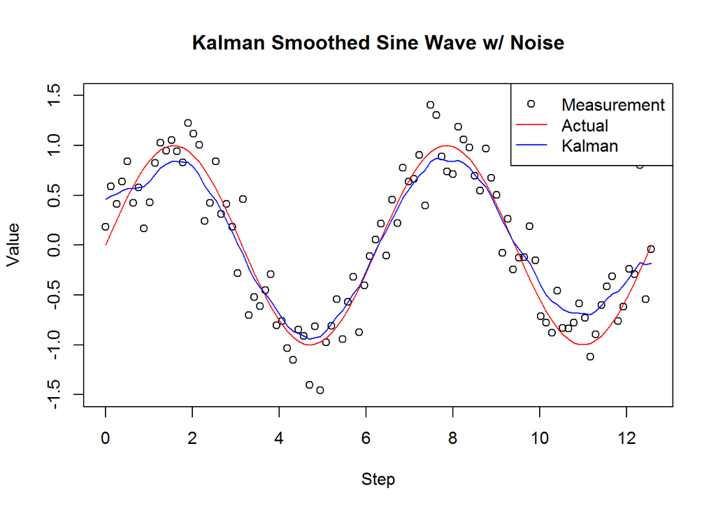

Kalman Smoother Mean Squared Error:

```
## [1] 2.39235
```

Kalman Smoother R-Squared:

```
## [1] 0.9721075
```